# Newspaper coverage of wars in the 21st century

Computational Social Science - 2022

Samuel Rauh

# Introduction

The relationship between the media and wars has always been a controversial one. In such times it is very difficult to get down to the source and the large media companies are most of the time the only ones which have the ability to cover the state of a war since a whole region is in a state of emergency and it is almost impossible for normal citizens to get information otherwise. The media is in a critical position because they have the crucial ability to get the information and it is their determination to distribute it. But from the perspective of the media they are companies with a financial incentive. They earn a lot of money from international crises. The two motives of being a reliable source and attracting a large audience might contradict with each other. In addition have most large media groups a stronger or less strong political agenda which they push and which can have a severe impact on how they cover news. This can result in multiple extremely different portrayals of the same topic. This critical role of the media in times of war has motivated me to have a closer look at how different media sources portray different wars.

# Methods

To collect the data I use the “The Guardian” API of the British newspaper and the “New York Times” API of the American Newspaper. After cleaning up the data I will perform three text analysis procedures. First a sentiment analysis to check if there are differences in the positivity score between the wars but also between the two newspapers. Second I will do a word frequency analysis and look at the most used words. And third I will use the ” Lexicoder policy agendas” dictionary to do a topic analysis. I chose to look at three different wars: The war in Afghanistan, the war going on right now in the Ukraine and the civil war in Syria. I have chosen those three because they are all different from each other in the point of how the “West” relates to them. The war in Afghanistan was driven by the USA following the 9/11 terrorist attack in New York. The war in Ukraine is geographically and also politically closer to the “West” but western forces have (not yet) intervened themselves. The war in Syria has been going on for a long time and has had a lot of media coverage in the past, it is geographically and cultural much further away from the “West” but the USA and its allies also have played a controversial role in it.

## Limitations

The primary limitation I had to set were the numbers of newspaper and wars I included in the analysis. I initially wanted to also use the “Die Zeit” API to have a newspaper in a different language and from another different country but the service has been stopped due to technical difficulties. Since there are only limited APIs I chose to stick to these two. But it would have been very interesting to also have a newspaper with a potentially right leaning political orientation since these two are both more liberal. I limited myself to those three wars since I don’t think that it would make much of a difference to look at more wars. I think that differences in the reporting of the wars would show when comparing these three. For further studies it would be interesting to look at wars from longer time ago. I’m sure there would be interesting finding when looking at the Vietnam war or even the 2. world war.

# Data Collection and Processing

*Not all code chunks are run or shown, this is for the reason of illustration and very long time of gathering the data. All the data used is saved in the “Data” folder,*

### Libraires

```r
library(dplyr)
library(quanteda)
library(jsonlite)
library(stringr)
library(tidyverse)
library(ggplot2)
library(rvest)
library(stringr)
library(quanteda.textplots)
```

## The Guardian

URL generator for the Guardian API

```r
guardian_key = read_lines("guardian_key.txt")

guardian_url = function(search_word, date_from='', date_to='') {
  search_word <- str_replace(search_word, ' ', '%20')

  if (date_from == '' | date_to == '') {
    url <- paste0('http://content.guardianapis.com/search?q=', search_word,
                  '&show-blocks=all&api-key=', guardian_key, sep='')
  } else {
    url <- paste0('http://content.guardianapis.com/search?q=', search_word,
                  '&from-date=', date_from, '&to-date=', date_to,
                  '&show-blocks=all&api-key=', guardian_key, sep='')
  }
  url
}
```

### Afghanistan War

#### Get Data

```r
#There are 63'723 articles which is too much, it exceeds the rate limit of the Guardian API
#that's why I will extract 10% of all the pages of each relevant year.

afgh_list <- vector("list")
counter <- 1

for (year in 1999:2022) {
  base_url <- guardian_url('afghanistan war', paste0(year, '-01-01'),
                           paste0(year, '-12-31'))
  n_results <- fromJSON(base_url) %>% .$response %>% .$total
  max_pages <- ceiling(((n_results[1] / 10)-1))
  random_pages <- sample.int(max_pages, max_pages/10)
  print(year)


  for(i in 1:(max_pages/10)){
    x=random_pages[i]
    print(i)
    url <- paste0(base_url, "&page=", x, sep='')
      GuardSearch <- fromJSON(url, flatten = TRUE) %>%
        data.frame(.,stringsAsFactors = FALSE)
    afgh_list[[counter]] <- GuardSearch
    counter <- counter + 1
    #Sys.sleep(1)
}
}

afgh_results <- rbind_pages(afgh_list)

save(afgh_results, file = "Data/afgh_results.RData")
```

#### Data Cleaning

```r
load('Data/afgh_results.RData')

#Pick filter out the results of the type "article"
afgh_results <- afgh_results %>%
  filter(response.results.type == "article") %>%
  unnest(cols = response.results.blocks.body)

# Make a selection of the important variables

afgh <- afgh_results %>%
  select(id = response.results.id,
         url = response.results.webUrl,
         title = response.results.webTitle,
         text = bodyTextSummary,
         date = response.results.webPublicationDate,
         section = response.results.sectionName,
         total_year = response.total
         )

afgh$text_len <- nchar(afgh$text)
summary(afgh$text_len)

afgh$text[afgh$text_len < 50]

#filter out articles with no significant text
afgh <- afgh %>%
  filter(!text %in% c("", " ", "."))
summary(afgh$text_len)

#extract date and year

afgh$date <- gsub("T.*",
                  "",
                  afgh$date) %>% as.Date()

afgh$year <- afgh$date %>%
  gsub("([0-9]{4}).*",
       "\\1", .) %>% as.numeric


afgh$total_year <- afgh$total_year %>%
  as.numeric

save(afgh, file = "Data/afgh.RData")
```

#### Basic Analysis

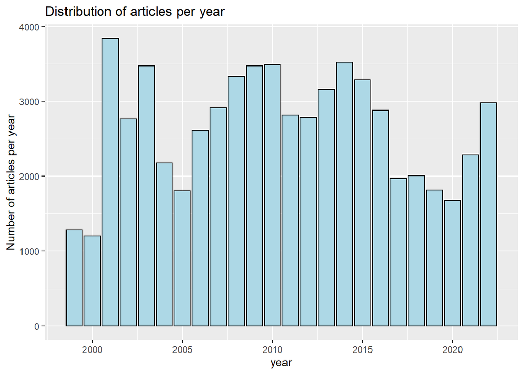

```r
# Create a histogram to show the distribution of articles

load("Data/afgh.RData")
afgh_hist <- ggplot(afgh, aes(x=date))+
  geom_histogram(binwidth = 200, fill='lightblue', color="black")+
  scale_x_date(date_breaks = "3 years", date_labels = "%Y")+
  theme_classic()


afgh_hist_year <- afgh[!duplicated(afgh[ , c("year")]), ] %>%
  select(total_year, year) %>%
  ggplot(aes(x=year, y=total_year))+
  geom_bar(stat='identity', fill = "lightblue", color="black")+
  labs(title = "Distribution of articles per year", y="Number of articles per year")
afgh_hist_year
```

#### Create a corpus and tokens

```r
afgh_corpus <- corpus(afgh,
                      text_field = "text")

summary(afgh_corpus) %>% head
docvars(afgh_corpus) %>%
  head

afgh_corpus[1]


afgh_toks <- tokens(afgh_corpus,
                    what = c("word"),
                    remove_separators = TRUE,
                    include_docvars = TRUE,
                    ngrams = 1L,
                    remove_numbers = FALSE,
                    remove_punct = TRUE,
                    remove_symbols = FALSE,
                    remove_hyphens = FALSE)

afgh_toks %>% head

afgh_toks <- afgh_toks %>%
  tokens_tolower %>%
  tokens_remove(stopwords("english"), padding = TRUE) %>%
  tokens_remove("") %>%
  tokens_wordstem(language = "english")

save(afgh_toks, file = "Data/afgh_toks.RData")
```

#### Sentiment Analysis

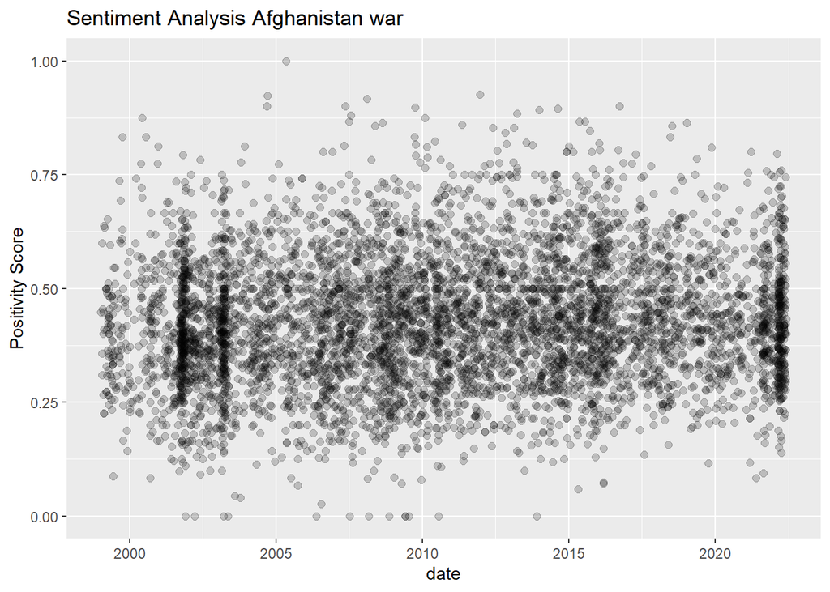

```r
load("Data/afgh_toks.RData")
load("Data/afgh.RData")

# make a sentiment analysis on the ratio of positive to negative words in each article

afgh_toks_sent <- tokens_lookup(afgh_toks,
                                dictionary =  data_dictionary_LSD2015[1:2])
#afgh_toks_sent %>% head

afgh_dfm_sent <- dfm(afgh_toks_sent)
#afgh_dfm_sent %>% head

afgh_pos_neg <- afgh_dfm_sent %>% convert(.,to = "data.frame") %>%
  mutate(pos_to_neg = (positive / (positive + negative)))

#summary(afgh_pos_neg)
# afgh_pos_neg %>% filter(is.na(afgh_pos_neg$pos_to_neg))
# 1 NA in year 2002
# Row has 0 negative and 0 positive -> NaN -> discard

afgh_sent <- afgh

afgh_sent$pos_neg <- afgh_pos_neg$pos_to_neg
afgh_sent <- afgh_sent %>% filter(!is.na(afgh_sent$pos_neg))

# create plots to show the results

plot_afgh_sent <- ggplot(afgh_sent, aes(x=date, y=pos_neg))+
  geom_point(size=2, alpha=0.2)+
  labs(title = "Sentiment Analysis Afghanistan war", y="Positivity Score")
plot_afgh_sent
```

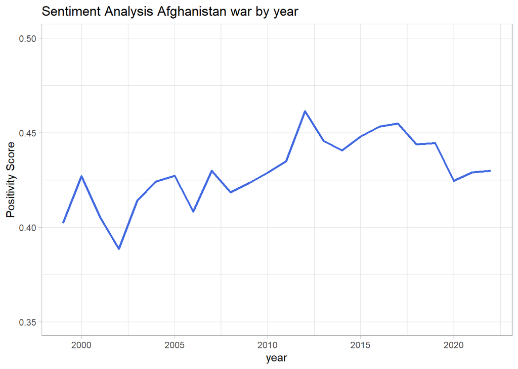

```r
afgh_by_year <- afgh_sent$pos_neg %>%
  aggregate(by=list(afgh_sent$year), FUN = mean) %>% rename(year = Group.1,
                                                       pos_neg = x)
# afgh_by_year

plot_afgh_pos_by_year <- ggplot(afgh_by_year, aes(x=year, y=pos_neg))+
  geom_line(color="royalblue", size=1)+
  theme_light()+
  ylim(0.35, 0.5)+
  labs(y="Positivity Score", title = "Sentiment Analysis Afghanistan war by year")
plot_afgh_pos_by_year
```

#### Word Frequency

```r
load("Data/afgh_toks.RData")


# load list with the most common words in English to remove them from the tokens

common_words <- read.delim("Data/1-1000.txt", header = FALSE) %>%
  head(200) %>%
  as.vector()
common_words <- common_words$V1

# removing the top 200 words from the tokens
afgh_toks_wordcount <- afgh_toks %>%
  tokens_remove(common_words)

afgh_dfm <- dfm(afgh_toks_wordcount)



afgh_topwords <- topfeatures(afgh_dfm, 50) %>%
  data.frame(word=names(.),
             frequency =.,
             row.names = c())

afgh_topwords
```

| word | frequency |
| --- | --- |
| war | 18408 |
| peopl | 10946 |
| govern | 8527 |
| countri | 7712 |
| afghanistan | 7167 |
| last | 7144 |
| forc | 6867 |
| iraq | 6318 |
| militari | 6204 |
| mani | 5707 |

[output cut: 40 more lines]

```r
save(afgh_dfm, file = "Data/afgh_dfm.RData")
```

#### Policy agendas analysis

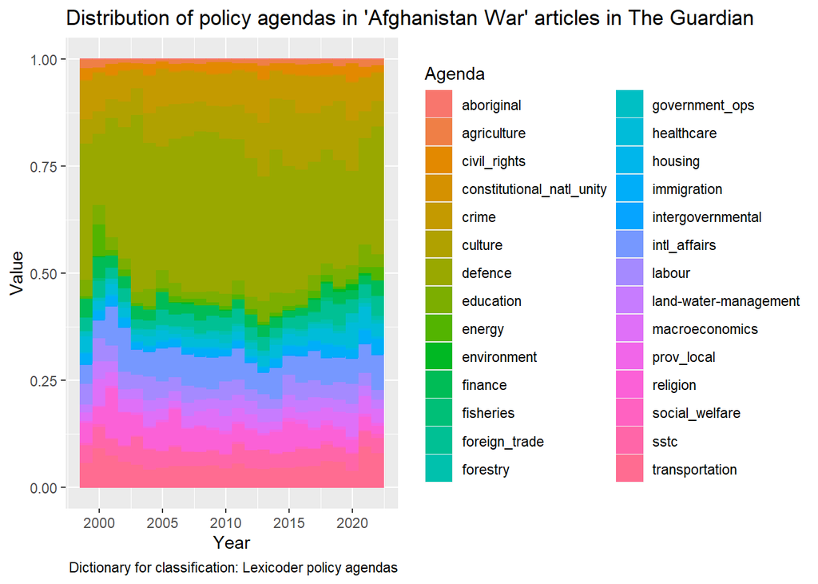

```r
load("Data/afgh_toks.RData")
load("Data/afgh.RData")

# Load the Lexicoder policy agendas
policyagendas <- dictionary(file = "Data/policy_agendas_english.lcd")

# lookup the policy agendas dictionary and give each article a score
afgh_toks_pol <- tokens_lookup(afgh_toks, dictionary = policyagendas)
afgh_pol <- dfm(afgh_toks_pol) %>%
  convert(to = "data.frame") %>%
  select(-doc_id)

# divide the values for each row through the sum of each row to get relative values for the agendas for each article
afgh_pol <- afgh_pol / rowSums(afgh_pol)

afgh_pol$year <- afgh$year

afgh_pol <- drop_na(afgh_pol)

# group by year
afgh_pol_by_year <- afgh_pol %>%
  group_by(year) %>%
  summarise_each(funs = sum)

# Plot the results to better inspect them
afgh_pol_by_year_plot1 <- afgh_pol_by_year %>%
  pivot_longer(cols = 2:29, names_to = "Agenda") %>%
  ggplot(aes(x=year, y=value, colour = Agenda, fill = Agenda))+
  geom_bar(position="fill", stat="identity")+
  labs(x="Year", y="Value", title="Distribution of policy agendas in 'Afghanistan War' articles in The Guardian",
       caption = "Dictionary for classification: Lexicoder policy agendas")
afgh_pol_by_year_plot1
```

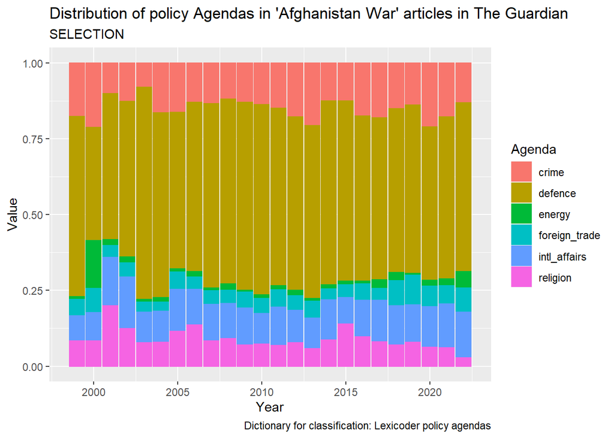

```r
# select some agendas which seam important
afgh_pol_by_year_plot_select <- afgh_pol_by_year %>%
  select(year, defence, energy, foreign_trade, intl_affairs, religion, crime) %>%
  pivot_longer(cols = 2:7, names_to = "Agenda") %>%
  ggplot(aes(x=year, y=value, colour = Agenda, fill = Agenda))+
  geom_bar(position="fill", stat="identity")+
  labs(x="Year", y="Value", title="Distribution of policy Agendas in 'Afghanistan War' articles in The Guardian",
       subtitle = "SELECTION", caption = "Dictionary for classification: Lexicoder policy agendas")
afgh_pol_by_year_plot_select
```

```r
save(afgh_pol, file = "Data/afgh_pol.RData")
```

The code for the other wars are not included in the rendered markdown since they are almost identical to the coverage of the Afghanistan War

### Syria War

#### Basic Analysis

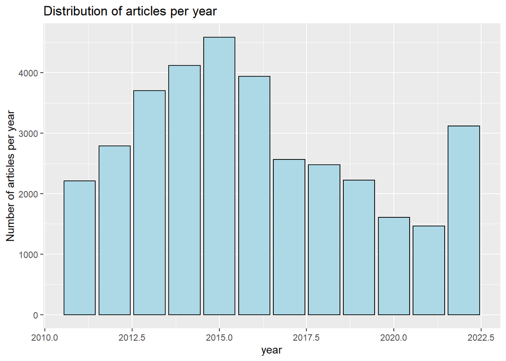

#### Sentiment Analysis

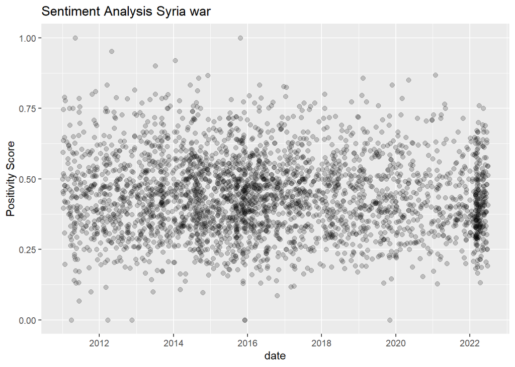

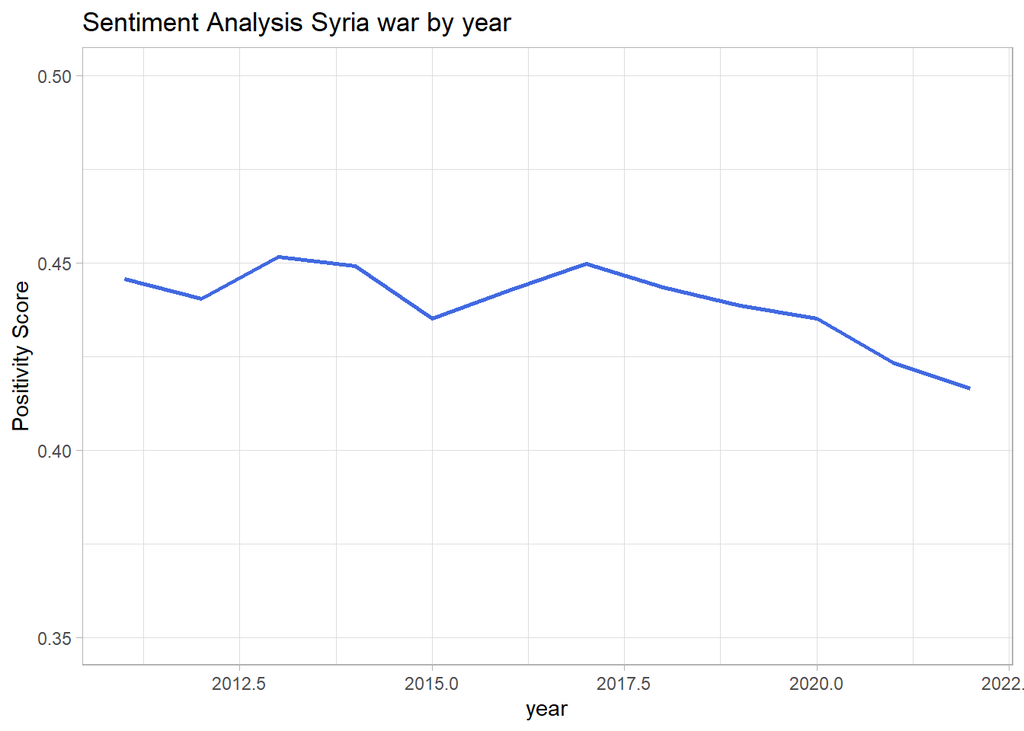

#### Word Frequency

| word | frequency |
| --- | --- |
| war | 8697 |
| peopl | 6562 |
| countri | 4552 |
| govern | 4493 |
| syria | 4228 |
| state | 3627 |
| forc | 3404 |
| last | 3367 |
| mani | 3016 |
| report | 2920 |

[output cut: 40 more lines]

#### Policy agendas analysis

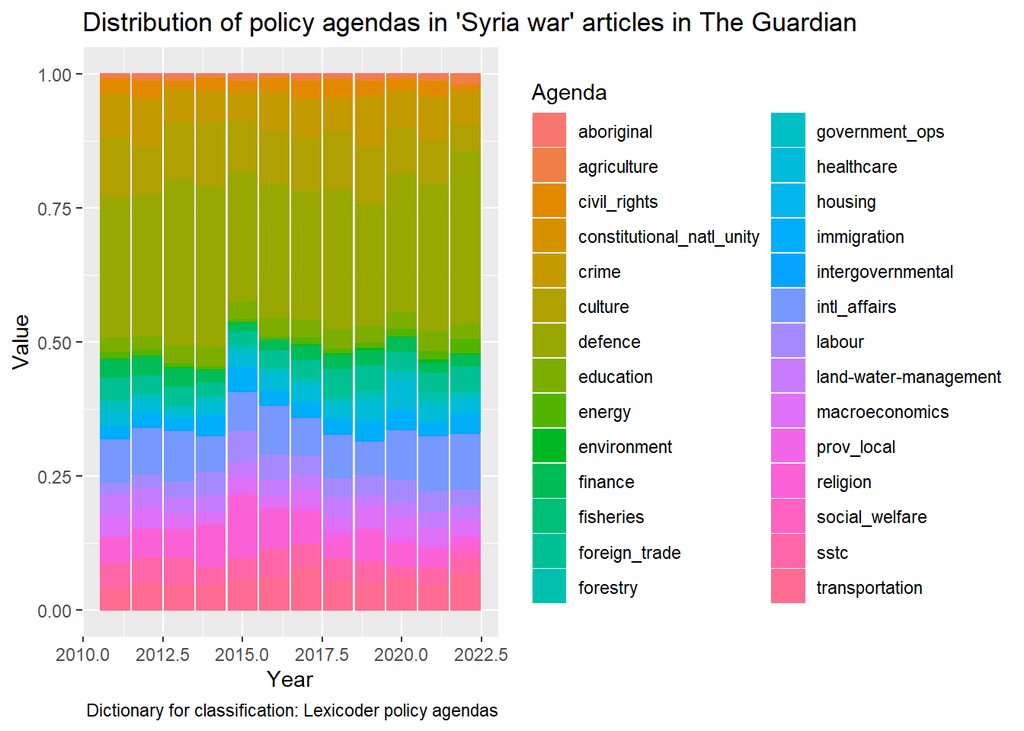

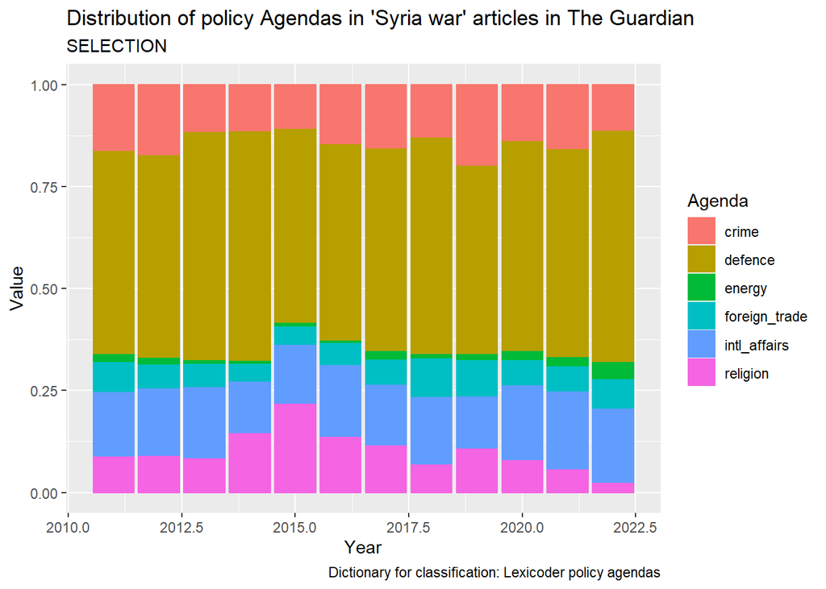

### Ukraine War

#### Basic Analysis

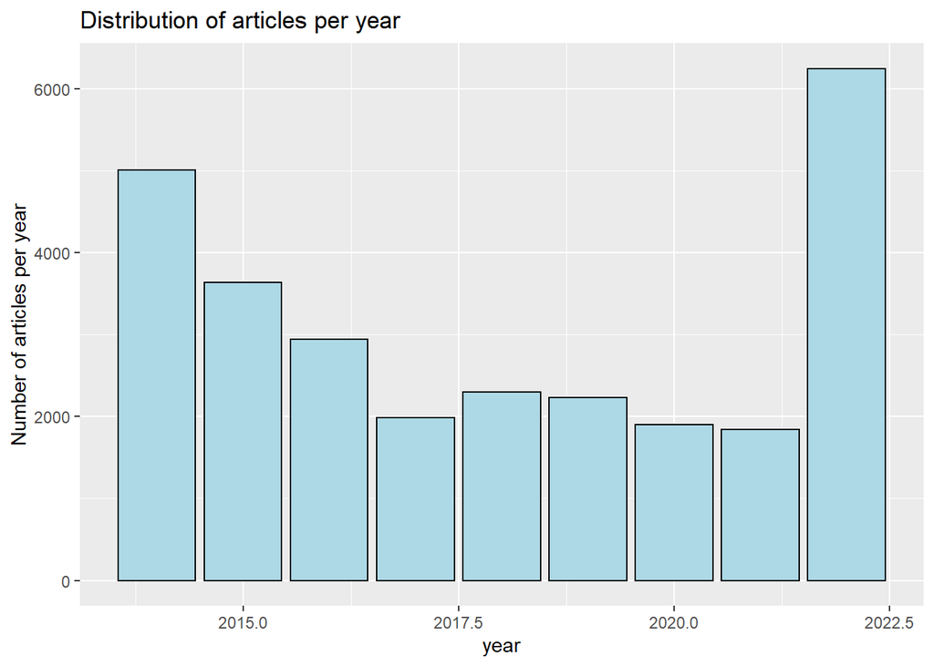

#### Sentiment Analysis

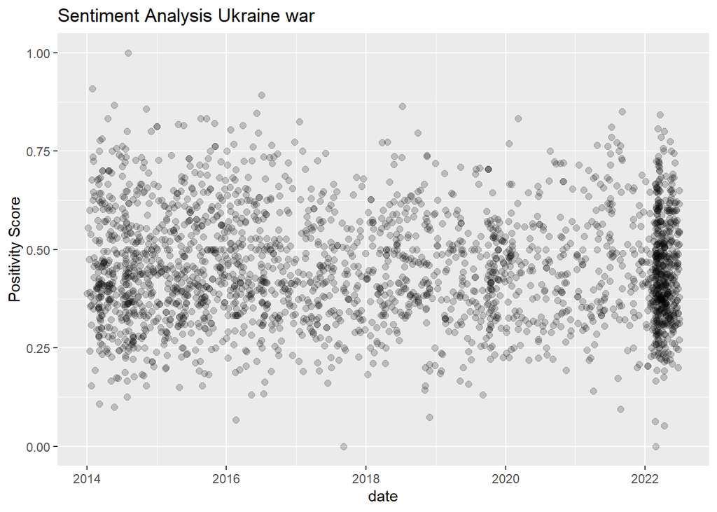

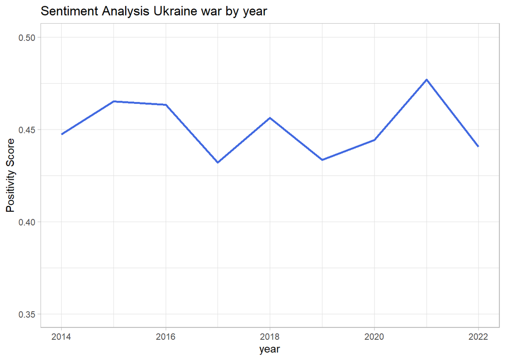

#### Word Frequency

| word | frequency |
| --- | --- |
| war | 6424 |
| peopl | 4819 |
| ukrain | 4593 |
| russia | 4298 |
| russian | 4141 |
| countri | 3395 |
| govern | 3256 |
| trump | 2949 |
| last | 2723 |
| presid | 2578 |

[output cut: 40 more lines]

#### Policy agendas analysis

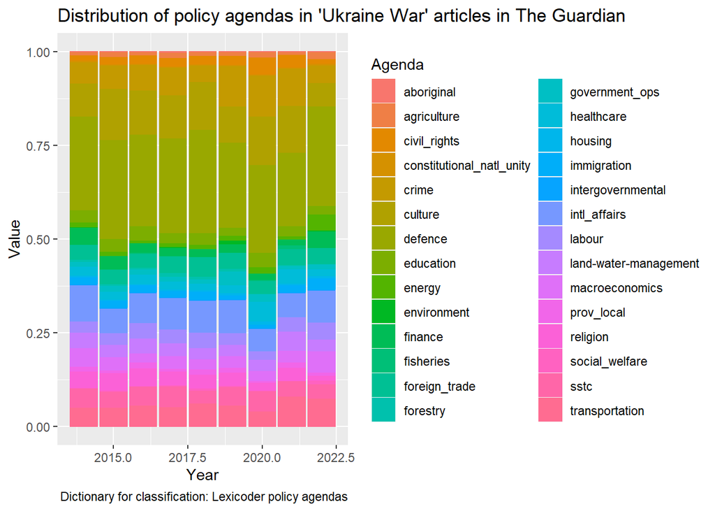

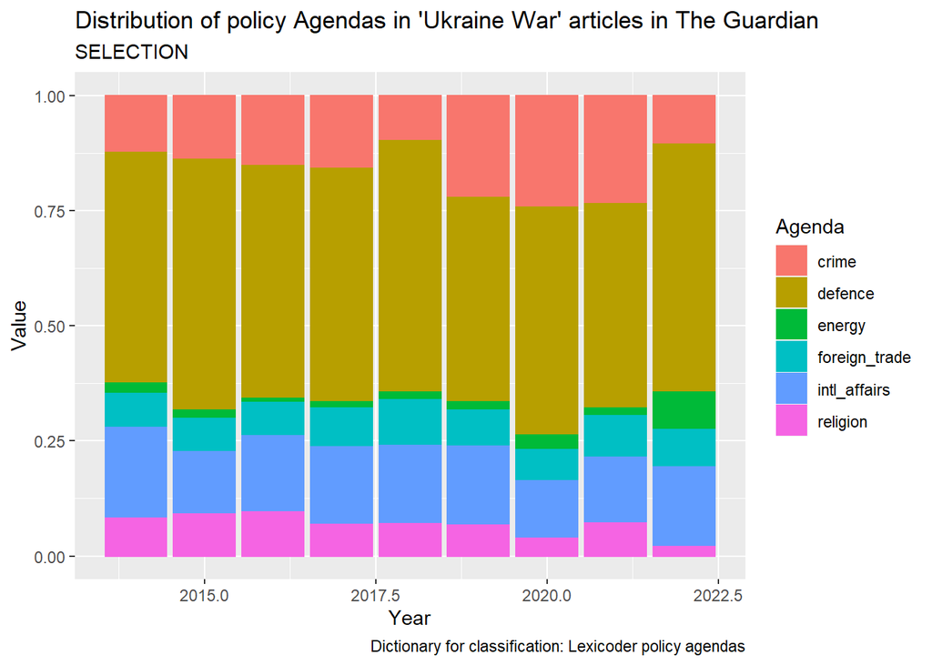

## New York Times

URL generator for the New York Times API

```r
nyt_key = read_lines("nyt_key.txt")

nyt_url <- function(search_word, date_from='', date_to='') {
  search_word <- str_replace(search_word, ' ', '%20')

  if (date_from == '' | date_to == '') {
    url <- paste0('http://api.nytimes.com/svc/search/v2/articlesearch.json?q=', search_word,
                  '&api-key=', nyt_key, sep='')
  } else {
    url <- paste0('http://api.nytimes.com/svc/search/v2/articlesearch.json?q=', search_word,
                  '&begin_date=', date_from, '&end_date=', date_to,
                  '&api-key=', nyt_key, sep='')
  }
  url

}
```

### Afghanistan War

#### Get Data

```r
nyt_afgh_list <- vector("list")

counter <- 1

# in the NYT API it is only possible to search until page 200

for (year in 1999:2022) {
  Sys.sleep(6)
  base_url <- nyt_url('afghanistan war', paste0(year, '-01-01'),
                           paste0(year, '-12-31'))
  print(base_url)
  n_results <- fromJSON(base_url) %>% .$response %>% .$meta %>% .$hits
  max_pages <-  ceiling(((n_results / 10)-1))

  if (max_pages > 200) {
    max_pages <- 200
  } else {}

  print(year)

  for(i in 1:(max_pages/10)){
      tryCatch({
      print(i)
      url <- paste0(base_url, "&page=", i, sep='')
        NYTSearch <- fromJSON(url, flatten = TRUE) %>%
          data.frame(.,stringsAsFactors = FALSE)
      nyt_afgh_list[[counter]] <- NYTSearch
      counter <- counter + 1
      Sys.sleep(6)
      }, error=function(e){
        message(paste0("Error at ", year, " Page:", i))
      })
  }

}

nyt_afgh_results <- rbind_pages(nyt_afgh_list)

save(nyt_afgh_results, file = "Data/nyt_afgh_results.RData")
```

#### Data Cleaning

```r
load("Data/nyt_afgh_results.RData")

glimpse(nyt_afgh_results)

# basic data cleaning and selection of important variables

nyt_afgh <- nyt_afgh_results %>%
  filter(response.docs.type_of_material == "News")%>%
  select(abstract = response.docs.abstract,
         date = response.docs.pub_date,
         keywords = response.docs.keywords,
         url = response.docs.web_url,
         word_count = response.docs.word_count,
         headline = response.docs.headline.main,
         id = response.docs._id,
         hits_year = response.meta.hits )

summary(nyt_afgh$word_count)

nyt_afgh <- nyt_afgh %>%
  filter(word_count >=50)

nyt_afgh$date <- nyt_afgh$date %>%
  gsub("T.*",
       "", .) %>%
  as.Date

nyt_afgh$year <- nyt_afgh$date %>%
  gsub("([0-9]{4}).*",
       "\\1", .) %>% as.numeric

glimpse(nyt_afgh)

save(nyt_afgh, file = "Data/nyt_afgh.RData")
```

#### Get Full articles

```r
load("Data/nyt_afgh.RData")

# the NYT API does not automatically include the article text. That's why I had to write a script to automatically collect the full text

# Some sites are no longer available
# That's why I need to remove the article at position 978

nyt_afgh <- nyt_afgh[-c(978),]

article_text <- vector("list")
count <- 1
error_tries <- 0


while(count <= length(nyt_afgh$url)) {
  tryCatch({
  url = nyt_afgh$url[count]
  raw <- read_html(url)
  text <- html_nodes(raw, "section p") %>% html_text() %>% paste(., collapse=" ")
  article_text[[count]] <- text
  print(count)
  count <- count + 1
  }, error=function(e){
        message(paste0("Error at ", count))
        if (error_tries == 0) {
          error_tries <- error_tries + 1
          Sys.sleep(30)
        } else {
          article_text[[count]] <- NA
          error_tries <- 0
          count <- count + 1
        }
      })
}




nyt_afgh$text <- article_text %>% as.character

glimpse(nyt_afgh)
head(nyt_afgh)

nyt_afgh <- nyt_afgh %>% filter(!is.na(nyt_afgh$text))

save(nyt_afgh, file = "Data/nyt_afgh.RData")
```

#### Basic Analysis

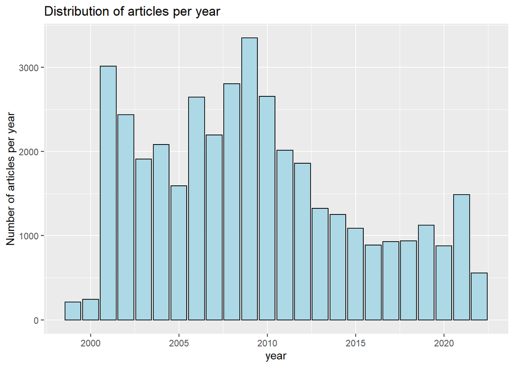

```r
load("Data/nyt_afgh.RData")

# Create a histogram to show the distribution of articles

nyt_afgh_hist <- ggplot(nyt_afgh, aes(x=date))+
  geom_histogram(fill="lightblue", color="black", binwidth = 200)
# nyt_afgh_hist


nyt_afgh_hist_year <- nyt_afgh[!duplicated(nyt_afgh[ , c("hits_year")]), ] %>%
  select(hits_year, year) %>%
  ggplot(aes(x=year, y=hits_year))+
  geom_bar(stat='identity', fill = "lightblue", color="black")+
  labs(title = "Distribution of articles per year", y="Number of articles per year")
nyt_afgh_hist_year
```

#### Create a corpus and tokens

```r
load("Data/nyt_afgh.RData")

nyt_afgh_corpus <- corpus(nyt_afgh,
                      text_field = "text")

summary(nyt_afgh_corpus) %>% head
docvars(nyt_afgh_corpus) %>%
  head

nyt_afgh_corpus[1]


nyt_afgh_toks <- tokens(nyt_afgh_corpus,
                    what = c("word"),
                    remove_separators = TRUE,
                    include_docvars = TRUE,
                    ngrams = 1L,
                    remove_numbers = FALSE,
                    remove_punct = TRUE,
                    remove_symbols = FALSE,
                    remove_hyphens = FALSE)

# nyt_afgh_toks %>% head

nyt_afgh_toks <- nyt_afgh_toks %>%
  tokens_tolower %>%
  tokens_remove(stopwords("english"), padding = TRUE) %>%
  tokens_remove("") %>%
  tokens_wordstem(language = "english")

save(nyt_afgh_toks, file = "Data/nyt_afgh_toks.RData")
```

#### Sentiment Analysis

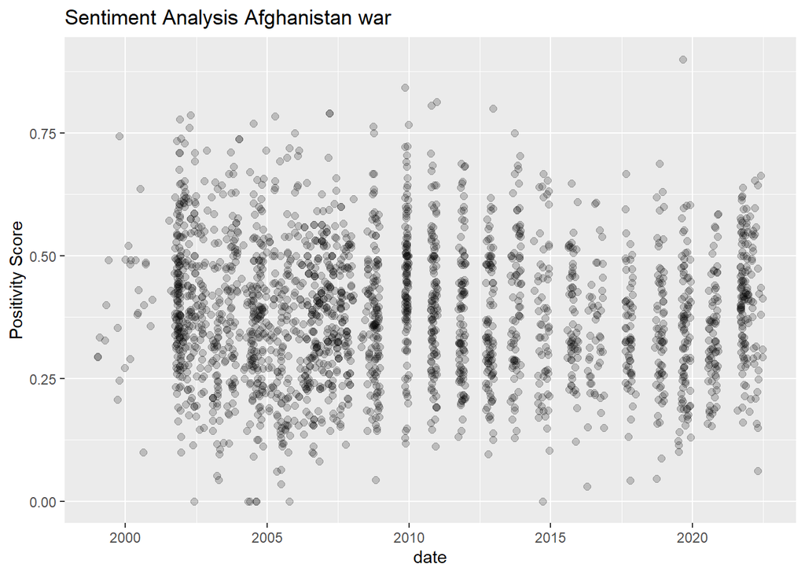

```r
load("Data/nyt_afgh_toks.RData")
load("Data/nyt_afgh.RData")

# make a sentiment analysis on the ratio of positive to negative words in each article

nyt_afgh_toks_sent <- tokens_lookup(nyt_afgh_toks,
                                dictionary =  data_dictionary_LSD2015[1:2])
# nyt_afgh_toks_sent %>% head

nyt_afgh_dfm_sent <- dfm(nyt_afgh_toks_sent)
# nyt_afgh_dfm_sent %>% head

nyt_afgh_pos_neg <- nyt_afgh_dfm_sent %>% convert(.,to = "data.frame") %>%
  mutate(pos_to_neg = positive / (positive + negative))

# summary(nyt_afgh_pos_neg)
#nyt_afgh_pos_neg %>% filter(is.na(nyt_afgh_pos_neg$pos_to_neg))
# 1 NA in year 2002
# Row has 0 negative and 0 positive -> NaN -> discard

nyt_afgh_sent <- nyt_afgh

nyt_afgh_sent$pos_neg <- nyt_afgh_pos_neg$pos_to_neg
nyt_afgh_sent <- nyt_afgh_sent %>% filter(!is.na(nyt_afgh_sent$pos_neg))

plot_nyt_afgh_sent <- ggplot(nyt_afgh_sent, aes(x=date, y=pos_neg))+
  geom_point(size=2, alpha=0.2)+
  labs(title = "Sentiment Analysis Afghanistan war", y="Positivity Score")
plot_nyt_afgh_sent
```

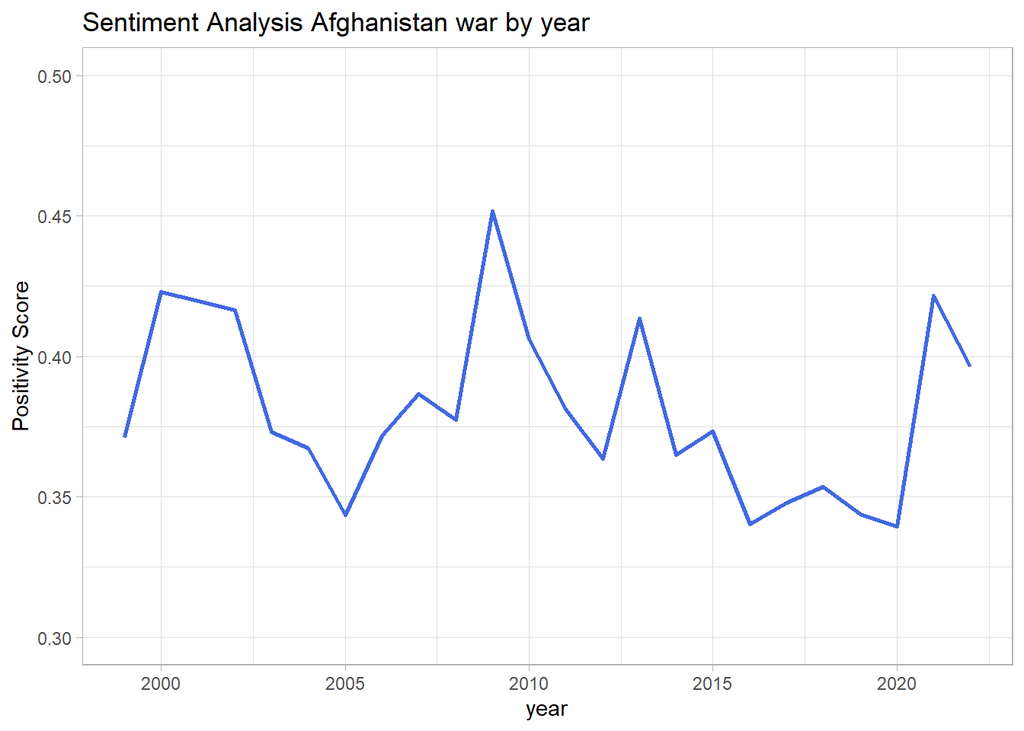

```r
nyt_afgh_by_year <- nyt_afgh_sent$pos_neg %>%
  aggregate(by=list(nyt_afgh_sent$year), FUN = mean) %>% rename(year = Group.1,
                                                                pos_neg = x)
# nyt_afgh_by_year

plot_nyt_afgh_pos_by_year <- ggplot(nyt_afgh_by_year, aes(x=year, y=pos_neg))+
  geom_line(color="royalblue", size=1, aes(group=1))+
  theme_light()+
  ylim(0.3, 0.5)+
  labs(title = "Sentiment Analysis Afghanistan war by year", y="Positivity Score")
plot_nyt_afgh_pos_by_year
```

#### Word Frequency

```r
load("Data/nyt_afgh_toks.RData")


# load list with the most common words in English to remove them from the tokens

common_words <- read.delim("Data/1-1000.txt", header = FALSE) %>%
  head(200) %>%
  as.vector()
common_words <- common_words$V1

# removing the top 200 words from the tokens
nyt_afgh_toks_wordcount <- nyt_afgh_toks %>%
  tokens_remove(common_words)

nyt_afgh_dfm <- dfm(nyt_afgh_toks_wordcount)



nyt_afgh_topwords <- topfeatures(nyt_afgh_dfm, 50) %>%
  data.frame(word=names(.),
             frequency =.,
             row.names = c())

nyt_afgh_topwords
```

| word | frequency |
| --- | --- |
| afghanistan | 15253 |
| mr | 14062 |
| taliban | 13462 |
| afghan | 12379 |
| american | 11601 |
| forc | 9176 |
| offici | 9136 |
| kill | 8058 |
| militari | 7440 |
| unit | 7108 |

[output cut: 40 more lines]

```r
save(nyt_afgh_dfm, file = "Data/nyt_afgh_dfm.RData")
```

#### Policy agendas analysis

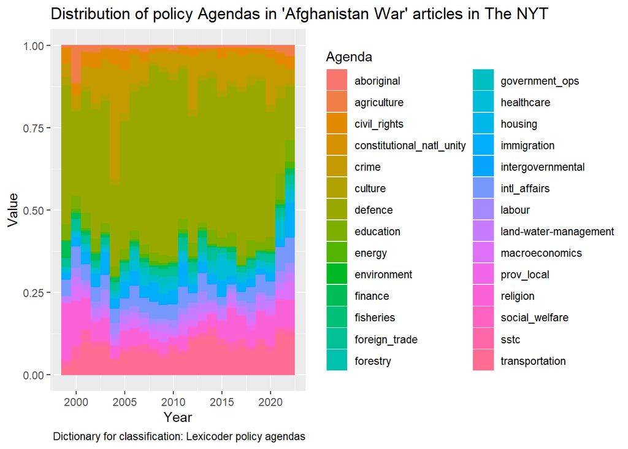

```r
load("Data/nyt_afgh_toks.RData")
load("Data/nyt_afgh.RData")

# Load the Lexicoder policy agendas
policyagendas <- dictionary(file = "Data/policy_agendas_english.lcd")

# lookup the policy agendas dictionary and give each article a score
nyt_afgh_toks_pol <- tokens_lookup(nyt_afgh_toks, dictionary = policyagendas)
nyt_afgh_pol <- dfm(nyt_afgh_toks_pol) %>%
  convert(to = "data.frame") %>%
  select(-doc_id)

# divide the values for each row through the sum of each row to get relative values for the agendas for each article
nyt_afgh_pol <- nyt_afgh_pol / rowSums(nyt_afgh_pol)

nyt_afgh_pol$year <- nyt_afgh$year

nyt_afgh_pol <- drop_na(nyt_afgh_pol)

nyt_afgh_pol_by_year <- nyt_afgh_pol %>%
  group_by(year) %>%
  summarise_each(funs = sum)

# Plot the results to better inspect them
nyt_afgh_pol_by_year_plot1 <- nyt_afgh_pol_by_year %>%
  pivot_longer(cols = 2:29, names_to = "Agenda") %>%
  ggplot(aes(x=year, y=value, colour = Agenda, fill = Agenda))+
  geom_bar(position="fill", stat="identity")+
  labs(x="Year", y="Value", title="Distribution of policy Agendas in 'Afghanistan War' articles in The NYT",
       caption = "Dictionary for classification: Lexicoder policy agendas")
nyt_afgh_pol_by_year_plot1
```

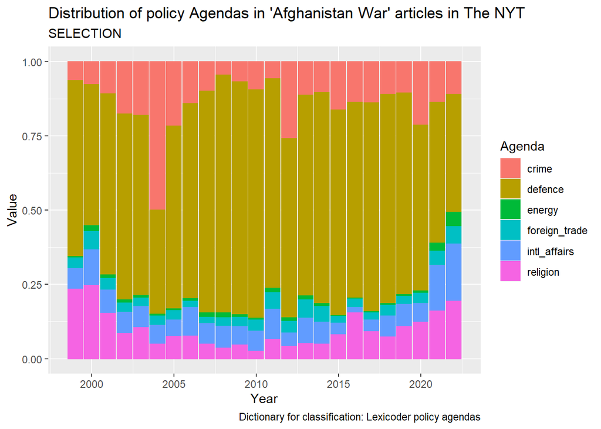

```r
# select some agendas which seam important
nyt_afgh_pol_by_year_plot_select <- nyt_afgh_pol_by_year %>%
  select(year, defence, energy, foreign_trade, intl_affairs, religion, crime) %>%
  pivot_longer(cols = 2:7, names_to = "Agenda") %>%
  ggplot(aes(x=year, y=value, colour = Agenda, fill = Agenda))+
  geom_bar(position="fill", stat="identity")+
  labs(x="Year", y="Value", title="Distribution of policy Agendas in 'Afghanistan War' articles in The NYT",
       subtitle = "SELECTION", caption = "Dictionary for classification: Lexicoder policy agendas")
nyt_afgh_pol_by_year_plot_select
```

```r
# nyt_afgh_pol_by_year

save(nyt_afgh_pol, file = "Data/nyt_afgh_pol.RData")
```

The code for the other wars are not included in the rendered markdown since they are almost identical to the coverage of the Afghanistan War

### Syria War

#### Basic Analysis

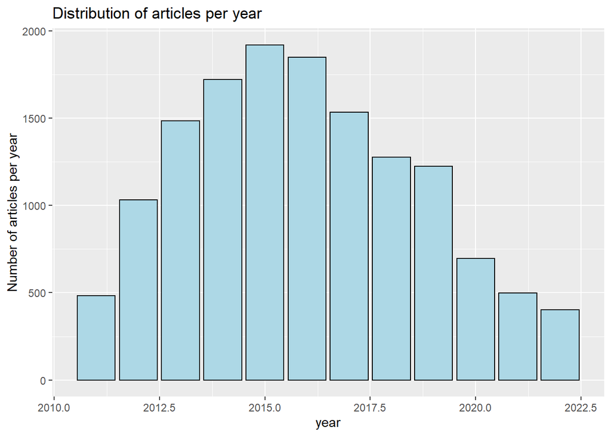

#### Sentiment Analysis

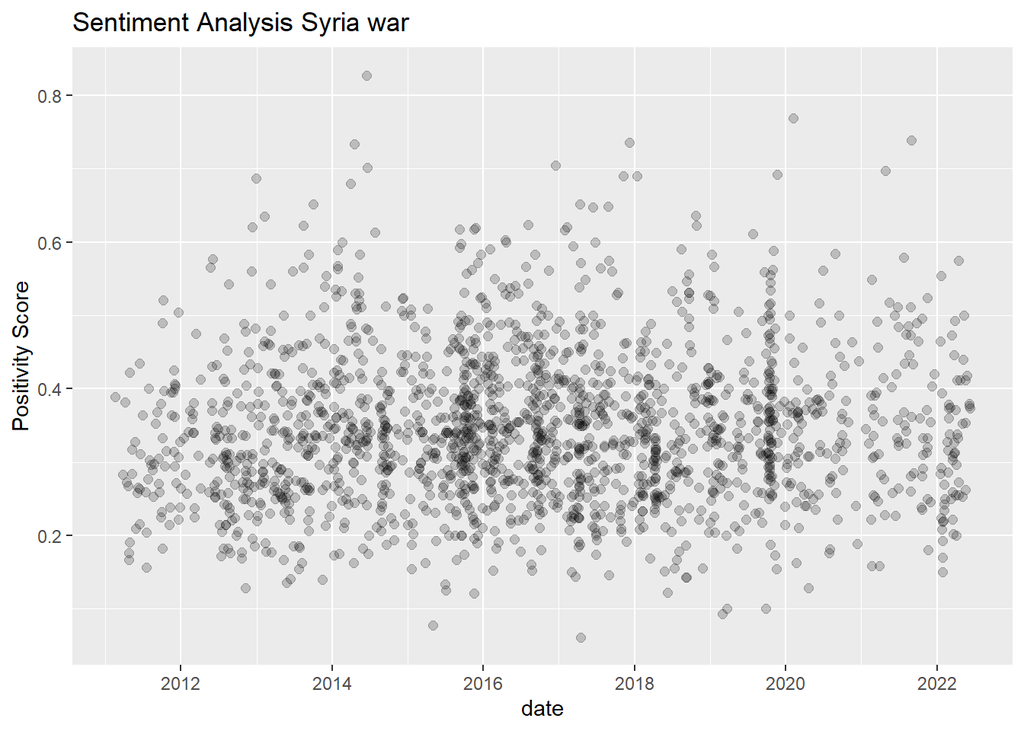

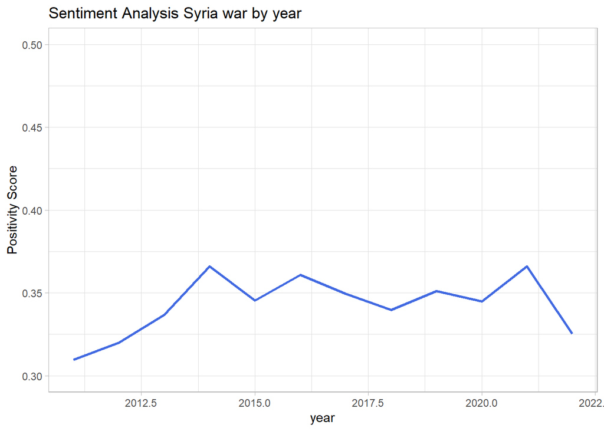

#### Word Frequency

| word | frequency |
| --- | --- |
| syria | 16362 |
| mr | 16331 |
| syrian | 13383 |
| state | 12716 |
| govern | 9394 |
| war | 9154 |
| unit | 8299 |
| forc | 8088 |
| group | 7090 |
| american | 5468 |

[output cut: 40 more lines]

#### Policy agendas analysis

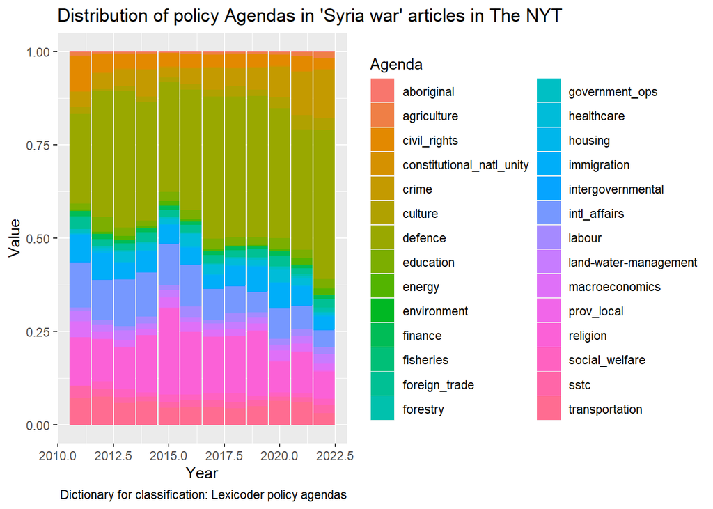

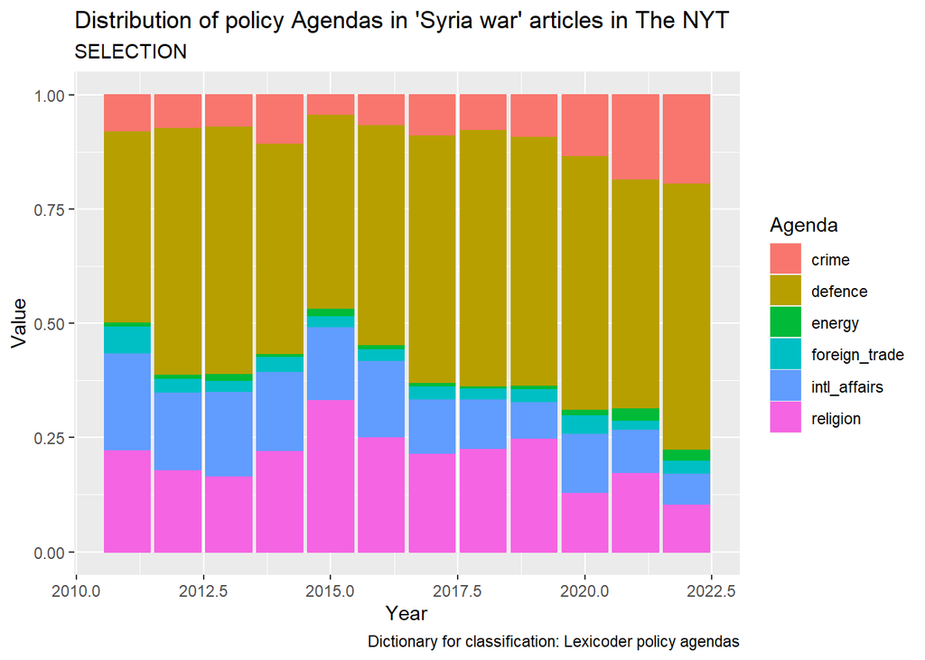

### Ukraine War

#### Basic Analysis

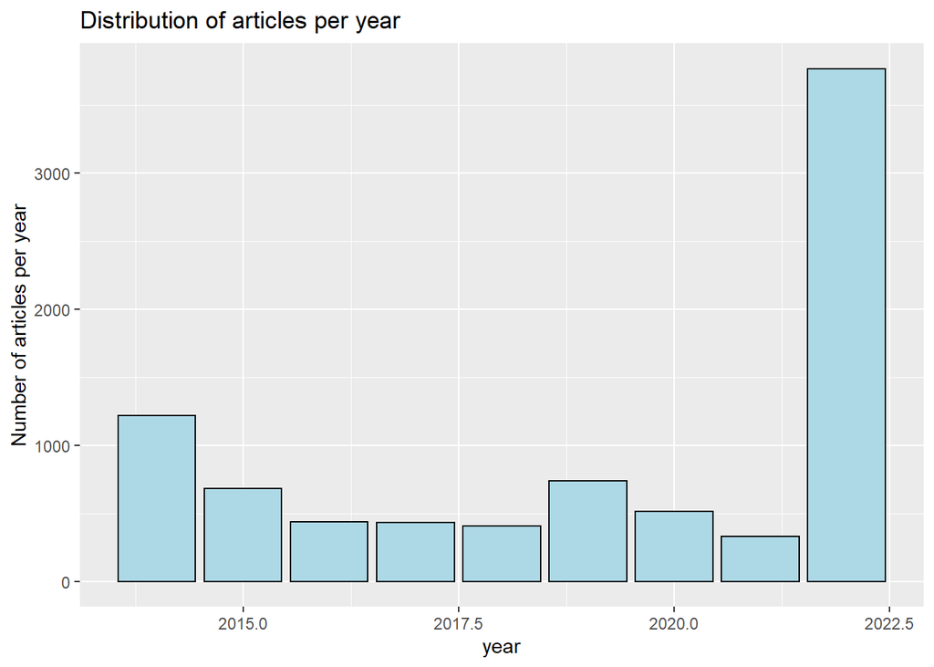

#### Sentiment Analysis

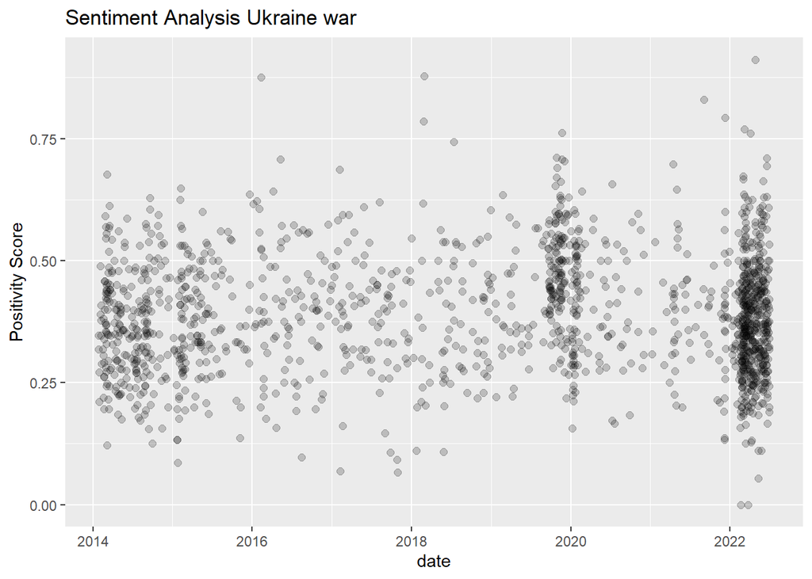

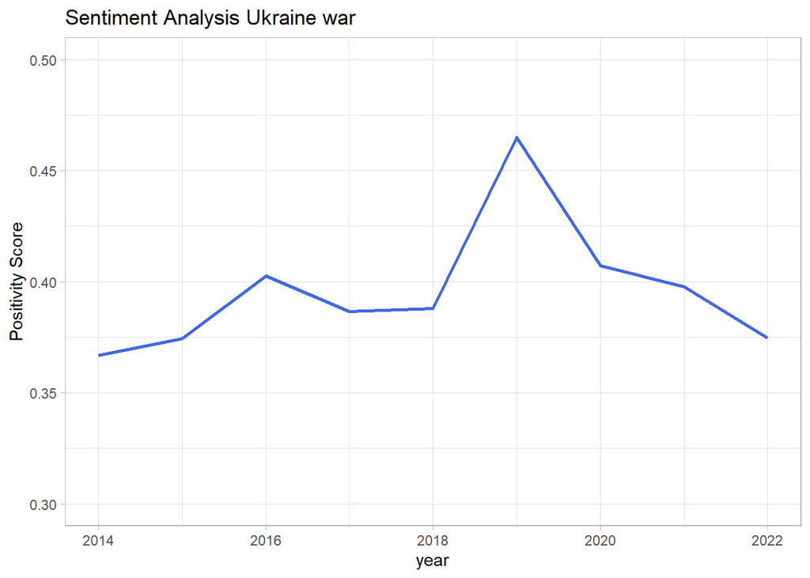

#### Word Frequency

| word | frequency |
| --- | --- |
| mr | 17994 |
| ukrain | 14357 |
| russia | 10526 |
| russian | 10172 |
| ukrainian | 7869 |
| presid | 6534 |
| war | 6147 |
| state | 5141 |
| militari | 4508 |
| putin | 4301 |

[output cut: 40 more lines]

#### Policy agendas analysis

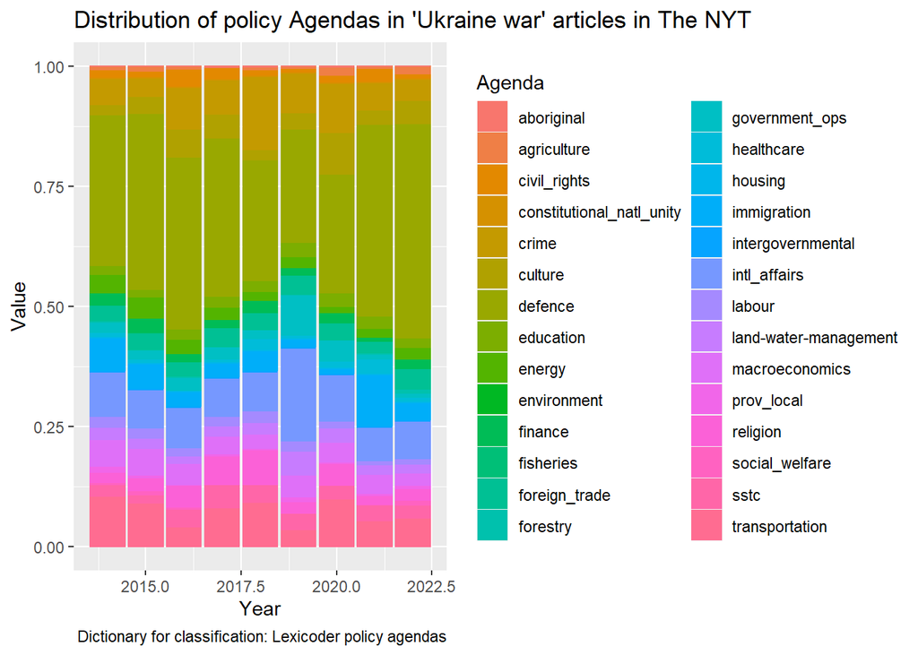

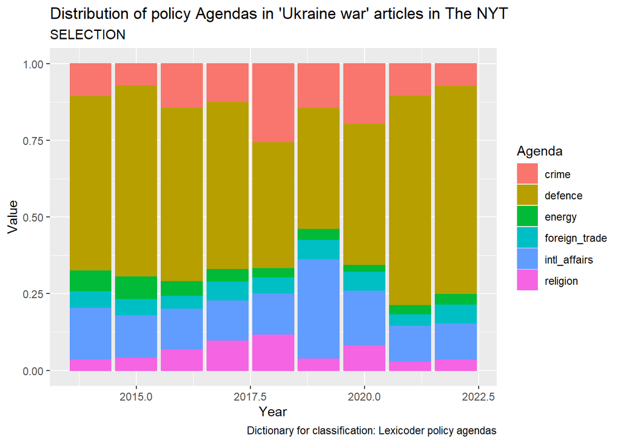